# EDA

## В нашем распоряжении датафрейм с данными о квартирах

Количество строчек / столбцов

```
(23368, 25)
```

Названия столбцов

```
['Unnamed: 0',
 'ID  объявления',
 'Количество комнат',
 'Тип',
 'Метро',
 'Адрес',
 'Площадь, м2',
 'Дом',
 'Парковка',
 'Цена',
 'Телефоны',
 'Описание',
 'Ремонт',
 'Площадь комнат, м2',
 'Балкон',
 'Окна',
 'Санузел',
 'Можно с детьми/животными',
 'Дополнительно',
 'Название ЖК',
 'Серия дома',
 'Высота потолков, м',
 'Лифт',
 'Мусоропровод',
 'Ссылка на объявление']
```

Количество пропусков по столбцам говорит нам о том, что работы предстоит много

```
Unnamed: 0                      0
ID  объявления                  0
Количество комнат            1041
Тип                             0
Метро                        1315
Адрес                           0
Площадь, м2                     0
Дом                             0
Парковка                    13417
Цена                            0
Телефоны                        0
Описание                        0
Ремонт                       2755
Площадь комнат, м2           8910
Балкон                       7978
Окна                         6613
Санузел                      2672
Можно с детьми/животными     6096
Дополнительно                 357
Название ЖК                 17520
Серия дома                  21205
Высота потолков, м          12162
Лифт                         5500
Мусоропровод                10522
Ссылка на объявление            0
dtype: int64
```

### Посмотрим признак rooms

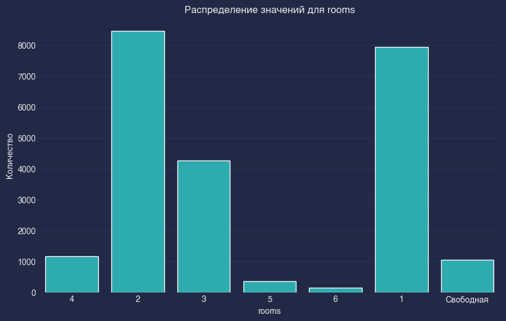

##### Видим, что чаще всего сдаются в аренду два пласта - **однушка** и **двушка**

### Посмотрим признак 'parking'

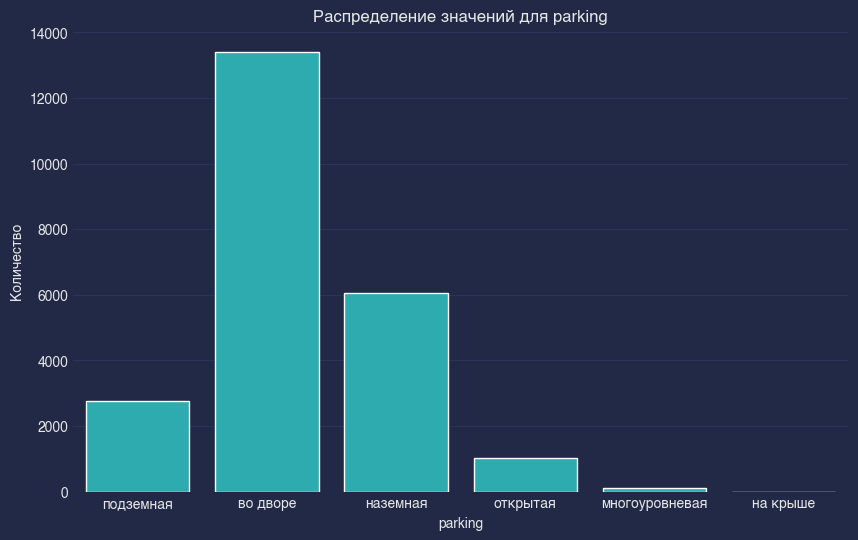

##### Тут видим, что дома обычно не имеют отдельно построенных парковок, они в основном назменые - либо для **жильцов** либо для **всех кто захочет**

### Рассмотрим признак square

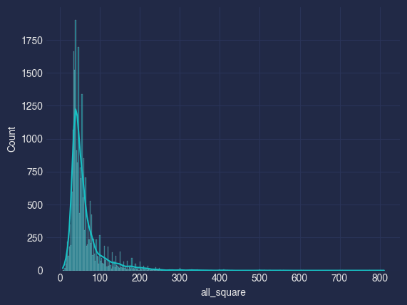

##### Мы можем видеть, что большинство квартир находятся в диапазоне от 40 до 70 метров квадратных

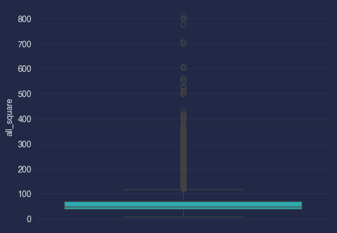

##### Медианное значение общей площади находится в районе 50, так же есть много квартир 150+ метров, это либо для тусовок посуточно, либо для аренды залов на мероприятия(конференции, свадьбы и тд) надо разбираться

### Посмотрим признак 'type'

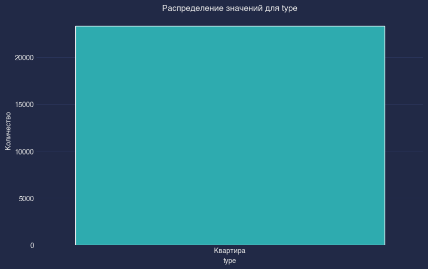

##### Здесь всего одно значение - **квартира**

### Посмотрим признак 'building'

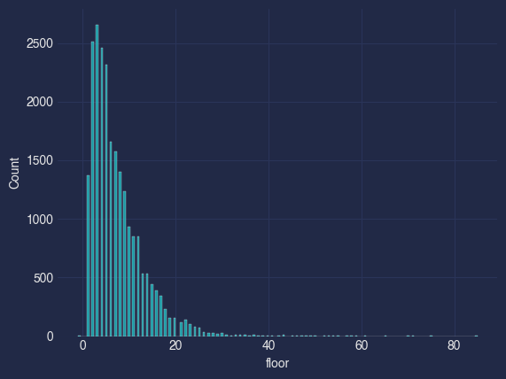

##### Большинство квартир находится на высоте от 1 до 15 этажа

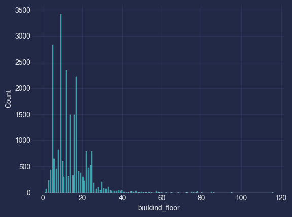

##### Большинство домов высотой - 9, 5, 12, 17, 16 скорее всего это так называемые **панельки** и **сталинки**

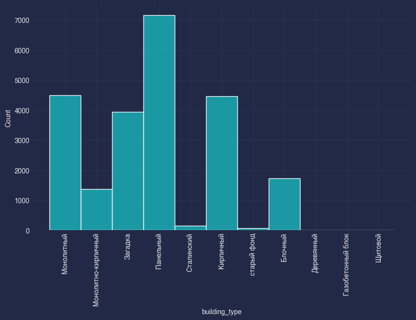

##### Больше всего **панелек**, **монолитных** и **кирпичных строений**

## Посмотрим признак цена

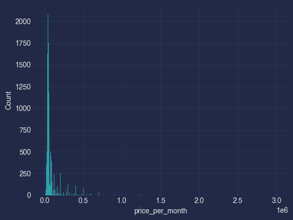

|  | announcement_id | all_square | floor | buildind_floor | price_per_month |
| --- | --- | --- | --- | --- | --- |
| count | 23,368.00 | 23,368.00 | 23,368.00 | 23,368.00 | 23,368.00 |
| mean | 267,626,523.83 | 62.82 | 7.36 | 14.11 | 82,894.14 |
| std | 18,768,615.25 | 46.70 | 5.85 | 8.81 | 122,696.20 |
| min | 107,298,592.00 | 7.00 | -1.00 | 1.00 | 5,000.00 |
| 25% | 271,266,347.00 | 38.00 | 3.00 | 9.00 | 37,000.00 |
| 50% | 273,903,027.50 | 48.00 | 6.00 | 12.00 | 49,500.00 |
| 75% | 274,687,218.50 | 70.00 | 10.00 | 17.00 | 75,000.00 |
| max | 275,006,443.00 | 811.00 | 85.00 | 116.00 | 3,000,000.00 |

#### Видим, что минимальная цена аренды 5000 - это либо комната, либо цена в валюте, надо разбираться

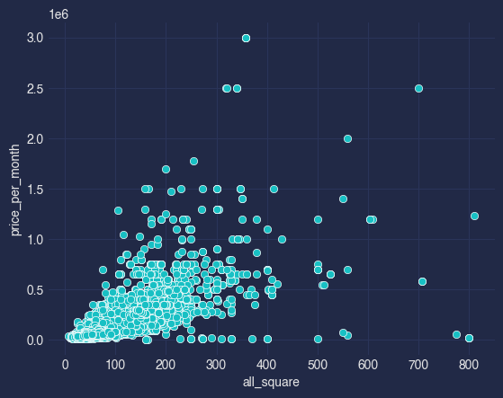

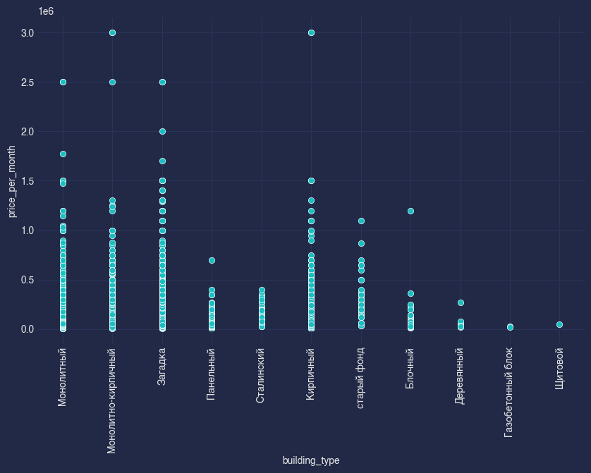

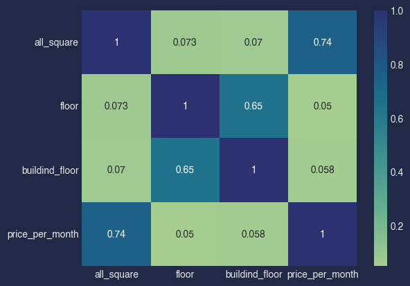

Признак "Ремонт" - категориальный номинальный. Не считая пропуски в наших данных есть 4 вида ремонта - Дизайнерский, Евроремонт, Косметический и без ремонта

```
Ремонт
Косметический   0.41
Евроремонт      0.41
Дизайнерский    0.17
Без ремонта     0.01
Name: proportion, dtype: float64
```

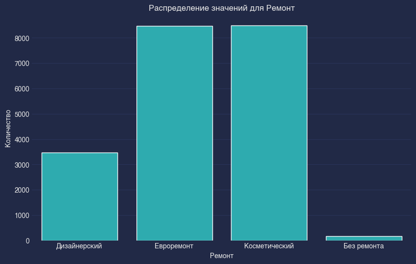

Признак "Площадь комнат" - количественный дискретный. В наших данных имеет все возможные способы записи (через -, +, / и пробел)

```
0                NaN
1        25 25 20 25
2                NaN
3        14-42-20-19
4              20 18
5                NaN
6     43-25-25-25-22
7           26 22 15
8           45 25 25
9        16 14 16 20
10       16-40-20-18
11               NaN
12                80
13               180
14               NaN
15               NaN
16               NaN
17               NaN
18               NaN
19    24-22-24-28-64
20             32-18
Name: Площадь комнат, м2, dtype: object
```

Признак "Балкон" дал нам 2 категории (Балкон и Лоджия), а так же количественный дискретный признак - количество тех самых балконов и лоджий в разных пропорциях

```
Балкон
Балкон (1)               0.48
Лоджия (1)               0.39
Балкон (1), Лоджия (1)   0.05
Лоджия (2)               0.04
Балкон (2)               0.03
Балкон (3)               0.00
Лоджия (3)               0.00
Балкон (2), Лоджия (2)   0.00
Балкон (1), Лоджия (2)   0.00
Балкон (2), Лоджия (1)   0.00
Балкон (4)               0.00
Балкон (3), Лоджия (1)   0.00
Балкон (1), Лоджия (3)   0.00
Лоджия (4)               0.00
Балкон (2), Лоджия (3)   0.00
Балкон (1), Лоджия (4)   0.00
Балкон (3), Лоджия (3)   0.00
Балкон (4), Лоджия (4)   0.00
Name: proportion, dtype: float64
```

Окна - категориальный номинальный признак с 3 вариантами. На улицу и двор, во двор и на улицу.

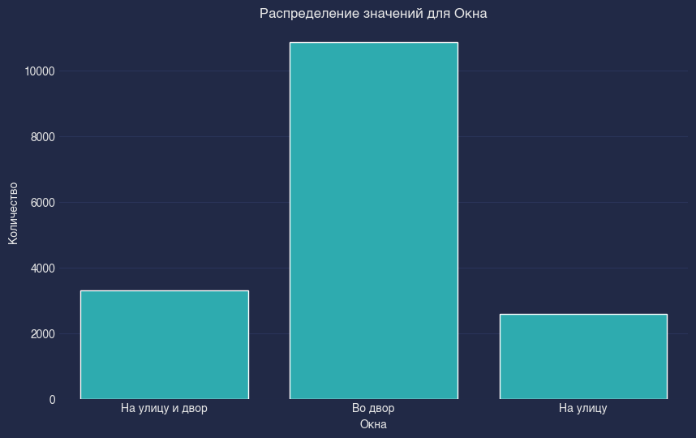

У санузлов мы опять видим 2 номинальные категории (Совмещенный и раздельный), а так же их дискретное количество

```
Санузел
Совмещенный (1)                   0.49
Раздельный (1)                    0.35
Совмещенный (2)                   0.07
Совмещенный (1), Раздельный (1)   0.04
Раздельный (2)                    0.03
Совмещенный (3)                   0.01
Совмещенный (2), Раздельный (1)   0.01
Совмещенный (4)                   0.00
Раздельный (3)                    0.00
Совмещенный (1), Раздельный (2)   0.00
Совмещенный (3), Раздельный (1)   0.00
Совмещенный (2), Раздельный (2)   0.00
Раздельный (4)                    0.00
Совмещенный (3), Раздельный (3)   0.00
Совмещенный (4), Раздельный (1)   0.00
Совмещенный (4), Раздельный (2)   0.00
Совмещенный (1), Раздельный (3)   0.00
Совмещенный (2), Раздельный (3)   0.00
Совмещенный (2), Раздельный (4)   0.00
Совмещенный (3), Раздельный (2)   0.00
Name: proportion, dtype: float64
```

Можно с детьми/животными - категориальный признак с 3 вариантами

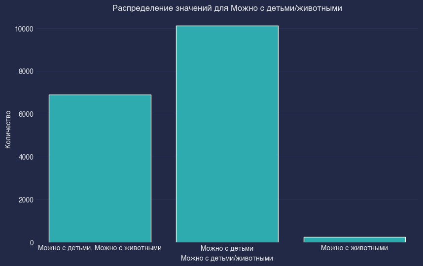

В признаке "Дополнительно" мы имеем разные комбинации из 11 бинарных признаков. По наличию разных штук в квартире.

```
{'Ванна',
 'Душевая кабина',
 'Интернет',
 'Кондиционер',
 'Мебель в комнатах',
 'Мебель на кухне',
 'Посудомоечная машина',
 'Стиральная машина',
 'Телевизор',
 'Телефон',
 'Холодильник'}
```

1798 различных Жилых комплексов (категориальный номинальный признак)

```
1798
```

Признак с 393 разными сериями домов (чтобы это ни значило)

```
393
```

Можно увидеть примерное распределение высоты потолков в квартирах

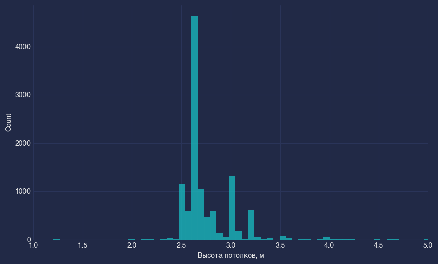

Мы можем наблюдать 2 номинальные категории (Пассажирский и грузовой лифт), а так же их дискретное количество

```
Лифт
Пасс (1)              0.33
Пасс (2)              0.24
Пасс (1), Груз (1)    0.22
Пасс (2), Груз (1)    0.07
Пасс (2), Груз (2)    0.04
Пасс (3)              0.04
Пасс (4)              0.02
Пасс (3), Груз (1)    0.01
Пасс (1), Груз (2)    0.01
Груз (1)              0.01
Пасс (4), Груз (2)    0.00
Пасс (4), Груз (1)    0.00
Пасс (3), Груз (3)    0.00
Пасс (3), Груз (2)    0.00
Пасс (4), Груз (4)    0.00
Груз (4)              0.00
Груз (2)              0.00
Груз (3)              0.00
Пасс (4), Груз (3)    0.00
Пасс (1), Груз (3)    0.00
Пасс (6)              0.00
Пасс (2), Груз (3)    0.00
Пасс (50)             0.00
Пасс (60)             0.00
Пасс (1), Груз (12)   0.00
Пасс (8), Груз (8)    0.00
Пасс (7)              0.00
Пасс (1), Груз (4)    0.00
Пасс (5), Груз (1)    0.00
Пасс (5), Груз (3)    0.00
Пасс (2), Груз (4)    0.00
Груз (6)              0.00
Груз (8)              0.00
Пасс (5)              0.00
Name: proportion, dtype: float64
```

Наличие муросопровода - бинарный категориальный признак.

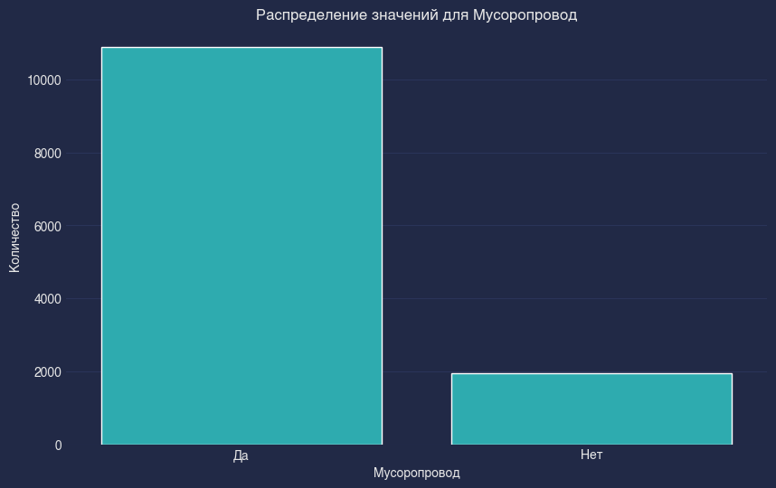

Ну и последний признак - ссылка на объявление. Может помочь для конкретизации какой-либо информации.